# Time

Ivan

2022-12-08

## Классификация:

## Выбор данных

```r
library("xlsx")
df <- read.xlsx(file = "MetroCommutes.xlsx", sheetIndex = 1)
df <- df[-1]
head(df)
```

```
##     City Distance Time
## 1 Boston        8   20
## 2 Boston        5   30
## 3 Boston       10   40
## 4 Boston       10   15
## 5 Boston       15   25
## 6 Boston       25   35
```

Просматривание пределов данных:

```r
summary(df)
```

```
##      City              Distance           Time
##  Length:1500        Min.   :  0.00   Min.   :  1.00
##  Class :character   1st Qu.:  5.00   1st Qu.: 12.00
##  Mode  :character   Median : 10.00   Median : 20.00
##                     Mean   : 14.05   Mean   : 24.53
##                     3rd Qu.: 20.00   3rd Qu.: 30.00
##                     Max.   :100.00   Max.   :161.00
```

## Описание данных

City: Города, в которых проводились исследования - Бостон, Хьюстон, Миннеаполис

Distance: Расстояние поездки на работу (в милях)

Time: Время в пути (в минутах)

## Pairs

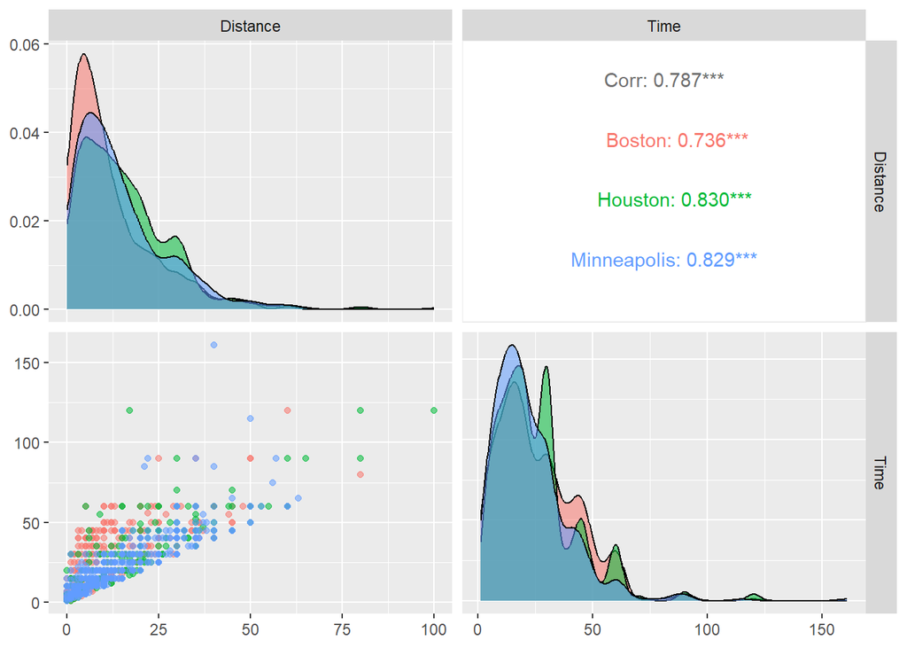

```r
num_col <- c("Distance","Time")
f <- ggpairs(df, columns = num_col,  diag = list(diag = list(continuous = "densityDiag", discrete = "blankDiag", na = "blankDiag")), cardinality_threshold=NULL, mapping = aes(color = df$City, alpha = 0.8))
print(f)
```

Видим, что распределения имеют хвосты вправо, необходимо пролагорифмировать.

## Логарифмируем

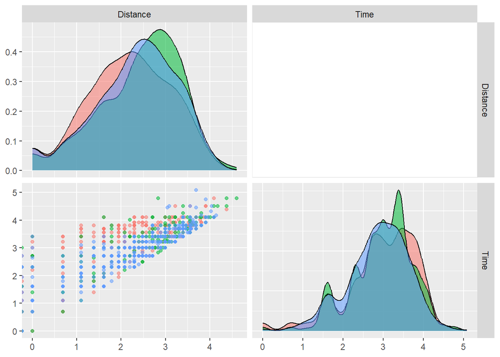

```r
df$Distance = log(df$Distance)
df$Time = log(df$Time)




f <- ggpairs(df, columns = num_col,  diag = list(diag = list(continuous = "densityDiag", discrete = "blankDiag", na = "blankDiag")), cardinality_threshold=NULL, mapping = aes(color = df$City, alpha = 0.8))
print(f)
```

```r
df <- df %>% filter(df$Distance != "-Inf")
```

## PCA

Посмотрим на данные в плоскости первых двух главных компанент, для этого:

```r
library("FactoMineR")
```

```r
result.pca = PCA(df, scale.unit=TRUE, ncp=2,quali.sup=1, graph=F)
```

Посмотрим на собственные числа, дисперсию и накопленную дисперсию соотвественно для каждой главной компаненты:

```r
result.pca$eig
```

```
##        eigenvalue percentage of variance cumulative percentage of variance
## comp 1  1.7915716               89.57858                          89.57858
## comp 2  0.2084284               10.42142                         100.00000
```

```r
library("factoextra")
```

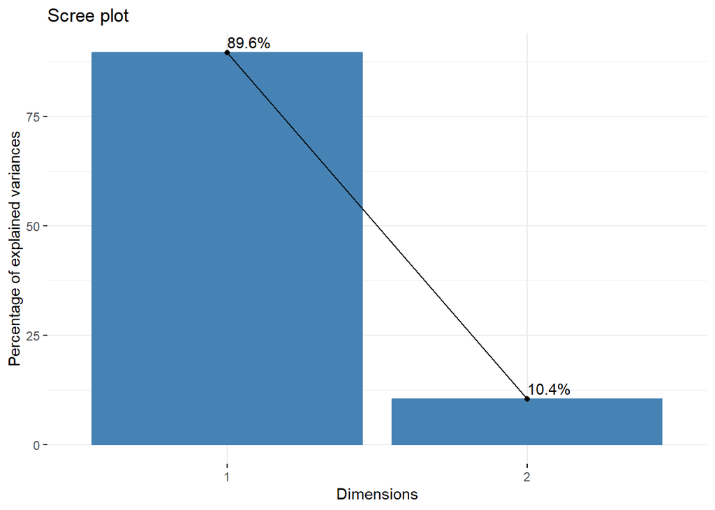

```r
fviz_eig(result.pca, addlabels = TRUE)
```

Вывод собственных векторов $U_i$:

```r
result.pca$svd$V
```

```
##           [,1]       [,2]
## [1,] 0.7071068 -0.7071068
## [2,] 0.7071068  0.7071068
```

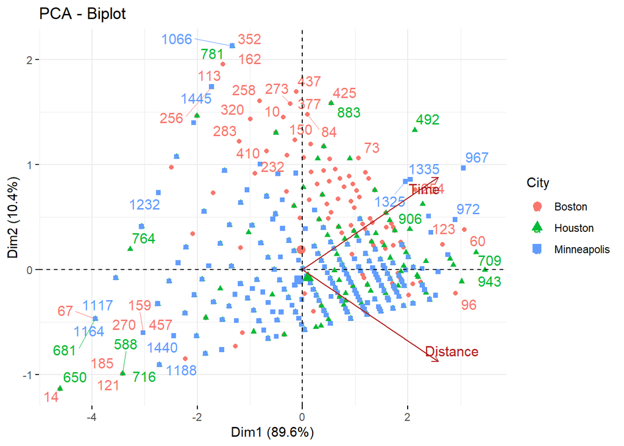

```r
fviz_pca_biplot(result.pca, repel = TRUE,habillage = 1,
                col.var = "#B22222",
                col.ind = "#008000"
                )
```

Также по форме распределений видим, что ковариационные матрицы классов отличаются (видим по разному наклону и ширине). Значит, теоретически, модель LDA не подходит.

Далее посмотрим на критерии Роя и Вилкса, для проверки гипотезы о том, что группы неразделимы:

```r
library(MASS)

df[2:3] <- scale(df[2:3])

set.seed(13)

Sample <- sample(c(TRUE,FALSE), nrow(df), replace=TRUE, prob =c(0.8,0.2))
train <- df[Sample,]
test <- df[!Sample,]


train.manova <- manova(cbind(Distance, Time) ~ City, data = train)

summary(train.manova, 'Wilks')
```

```
##             Df   Wilks approx F num Df den Df    Pr(>F)
## City         2 0.90283   30.101      4   2296 < 2.2e-16 ***
## Residuals 1149
## ---
## Signif. codes:  0 '***' 0.001 '**' 0.01 '*' 0.05 '.' 0.1 ' ' 1
```

```r
summary(train.manova, 'Roy')
```

```
##             Df     Roy approx F num Df den Df    Pr(>F)
## City         2 0.10404   59.768      2   1149 < 2.2e-16 ***
## Residuals 1149
## ---
## Signif. codes:  0 '***' 0.001 '**' 0.01 '*' 0.05 '.' 0.1 ' ' 1
```

По значениям лямбд Вилкса (0.9) и Роя (0.1) можем сделать вывод о том, что скорее всего группы разделимы только по одной канонической переменной.

## LDA

```r
LDAmodel <- lda(City~., data=train)
LDAmodel
```

```
## Call:
## lda(City ~ ., data = train)
##
## Prior probabilities of groups:
##      Boston     Houston Minneapolis
##   0.3255208   0.3402778   0.3342014
##
## Group means:
##                Distance        Time
## Boston      -0.12756291  0.16653623
## Houston      0.15913842  0.02594536
## Minneapolis  0.02653458 -0.09934551
##
## Coefficients of linear discriminants:
##                LD1        LD2
## Distance  1.644015 -0.5090983
## Time     -1.598478 -0.5686907
##
## Proportion of trace:
##    LD1    LD2
## 0.9696 0.0304
```

```r
LDAmodel_pred <- predict(LDAmodel, train)
```

В полученной модели приорные вероятности равны долям индивидов каждого класса по всей выборке.

Выше мы создали модель линейного дискрименантного анализа. Причем видим, что по первой канонической переменной групыы отличаются на 0.96, а по второй, всего на 0.03.

```r
predicted <- predict (LDAmodel, test)
head(predicted$posterior)
```

```
##       Boston   Houston Minneapolis
## 5  0.2770453 0.3740268   0.3489279
## 9  0.2754395 0.3564112   0.3681493
## 12 0.4687645 0.2223434   0.3088920
## 13 0.2421978 0.3671749   0.3906273
## 19 0.2252977 0.3856665   0.3890358
## 33 0.2745976 0.3876846   0.3377178
```

```r
mean(predicted$class==test$City)
```

```
## [1] 0.4060403
```

```r
table(predicted$class, test$City)
```

```
##
##               Boston Houston Minneapolis
##   Boston          41      30          21
##   Houston         26      48          51
##   Minneapolis     26      23          32
```

Модель определяет город с точностью 0.4. Сравним этот показатель с приорными вероятностями - он больше. Значит полученная модель работает лучше, чем если бы мы просто случайным образом относили индивид к одному из трех классов (0.4 > 0.33)

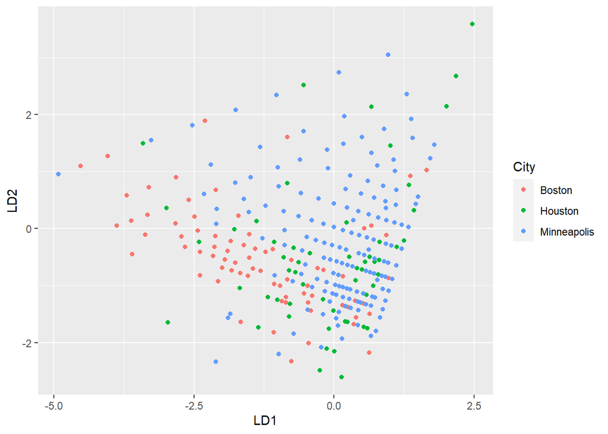

```r
lda_plot <- cbind(train, predict(LDAmodel)$x)
ggplot(lda_plot, aes (LD1, LD2)) + geom_point( aes (color = City))
```

## QDA

```r
QDAmodel <- qda(City~., data=train)
QDAmodel
```

```
## Call:
## qda(City ~ ., data = train)
##
## Prior probabilities of groups:
##      Boston     Houston Minneapolis
##   0.3255208   0.3402778   0.3342014
##
## Group means:
##                Distance        Time
## Boston      -0.12756291  0.16653623
## Houston      0.15913842  0.02594536
## Minneapolis  0.02653458 -0.09934551
```

```r
predicted <- predict (QDAmodel, test)
head(predicted$posterior)
```

```
##       Boston   Houston Minneapolis
## 5  0.2237369 0.3993526   0.3769104
## 9  0.2228457 0.3802122   0.3969421
## 12 0.4384070 0.2148815   0.3467114
## 13 0.2076240 0.3845770   0.4077990
## 19 0.2038454 0.3959389   0.4002158
## 33 0.2207691 0.4148780   0.3643530
```

```r
mean(predicted$class==test$City)
```

```
## [1] 0.3791946
```

```r
table(predicted$class, test$City)
```

```
##
##               Boston Houston Minneapolis
##   Boston          26      19          10
##   Houston         33      52          59
##   Minneapolis     34      30          35
```

Модель определяет город с точностью 0.37, что хуже, чем в случае LDA. А значит, хоть теоретически модель LDA нельзя применять к таким данным, однако, она работает точнее.

## ROC и AUC для LDA

Ниже представлена ROC кривая для train LDA

```r
train <- dplyr::filter(train, City %in% c("Boston","Minneapolis"))
test <- dplyr::filter(test, City %in% c("Boston","Minneapolis"))

LDAmodel <- lda(City~., data=train)
LDAmodel
```

```
## Call:
## lda(City ~ ., data = train)
##
## Prior probabilities of groups:
##      Boston Minneapolis
##   0.4934211   0.5065789
##
## Group means:
##                Distance        Time
## Boston      -0.12756291  0.16653623
## Minneapolis  0.02653458 -0.09934551
##
## Coefficients of linear discriminants:
##                LD1
## Distance  1.467386
## Time     -1.559630
```

```r
LDAmodel_pred <- predict(LDAmodel, train)

predicted <- predict (LDAmodel, test)
head(predicted$posterior)
```

```
##      Boston Minneapolis
## 1 0.4502623   0.5497377
## 2 0.4344541   0.5655459
## 3 0.5809649   0.4190351
## 4 0.3934324   0.6065676
## 5 0.3805826   0.6194174
## 6 0.4574035   0.5425965
```

```r
mean(predicted$class==test$City)
```

```
## [1] 0.6395939
```

```r
table(predicted$class, test$City)
```

```
##
##               Boston Minneapolis
##   Boston          47          25
##   Minneapolis     46          79
```

```r
library(ROCR)
```

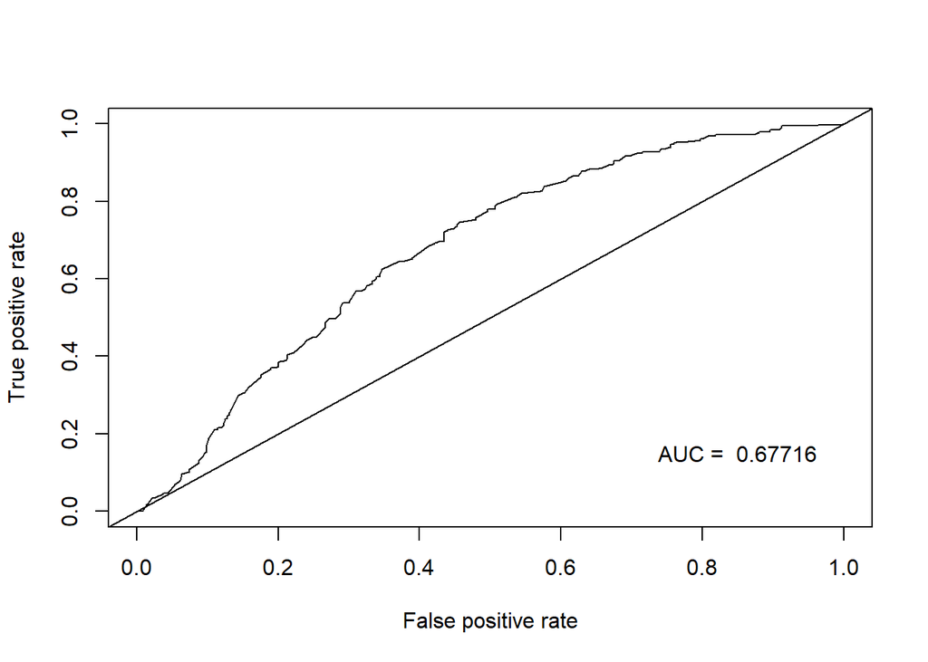

```r
pred <- prediction(LDAmodel_pred$posterior[,2], train$City)
perf <- performance(pred,"tpr","fpr")
plot(perf,colorize=FALSE)
AUC <- performance(pred,"auc")
abline(a = 0, b = 1)
text(x=0.85, y=0.15, paste("AUC = ", round(AUC@y.values[[1]],5)))
```

Ниже представлена ROC кривая для test LDA

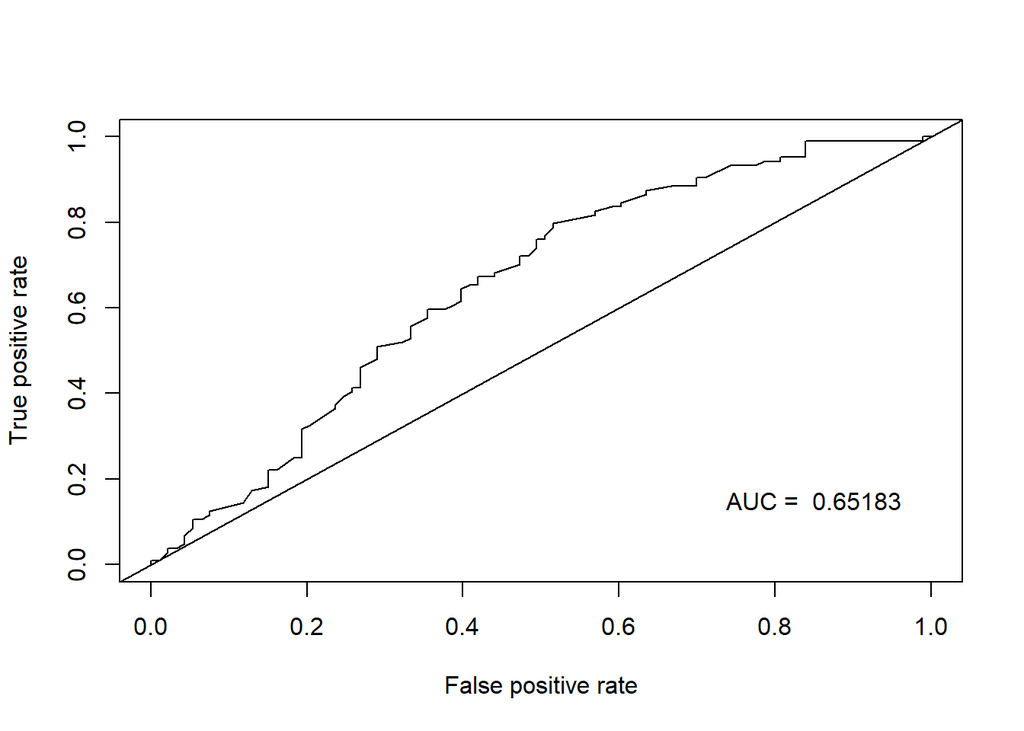

```r
pred <- prediction(predicted$posterior[,2], test$City)
perf <- performance(pred,"tpr","fpr")
plot(perf,colorize=FALSE)
AUC <- performance(pred,"auc")
abline(a = 0, b = 1)
text(x=0.85, y=0.15, paste("AUC = ", round(AUC@y.values[[1]],5)))
```

## ROC и AUC для QDA

Ниже представлена ROC кривая для train QDA

```r
QDAmodel <- qda(City~., data=train)
QDAmodel
```

```
## Call:
## qda(City ~ ., data = train)
##
## Prior probabilities of groups:
##      Boston Minneapolis
##   0.4934211   0.5065789
##
## Group means:
##                Distance        Time
## Boston      -0.12756291  0.16653623
## Minneapolis  0.02653458 -0.09934551
```

```r
QDAmodel_pred <- predict(QDAmodel, train)

predicted <- predict (QDAmodel, test)
head(predicted$posterior)
```

```
##      Boston Minneapolis
## 1 0.3724930   0.6275070
## 2 0.3595516   0.6404484
## 3 0.5583960   0.4416040
## 4 0.3373680   0.6626320
## 5 0.3374582   0.6625418
## 6 0.3773043   0.6226957
```

```r
mean(predicted$class==test$City)
```

```
## [1] 0.6192893
```

```r
table(predicted$class, test$City)
```

```
##
##               Boston Minneapolis
##   Boston          30          12
##   Minneapolis     63          92
```

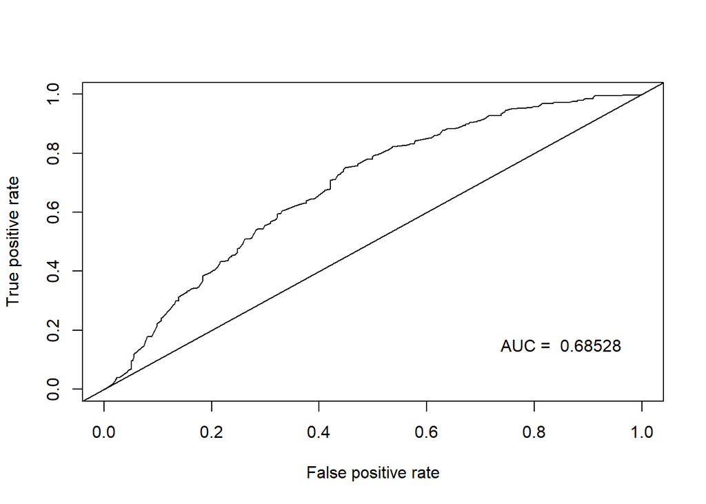

```r
library(ROCR)

pred <- prediction(QDAmodel_pred$posterior[,2], train$City)
perf <- performance(pred,"tpr","fpr")
plot(perf,colorize=FALSE)
AUC <- performance(pred,"auc")
abline(a = 0, b = 1)
text(x=0.85, y=0.15, paste("AUC = ", round(AUC@y.values[[1]],5)))
```

Ниже представлена ROC кривая для test QDA

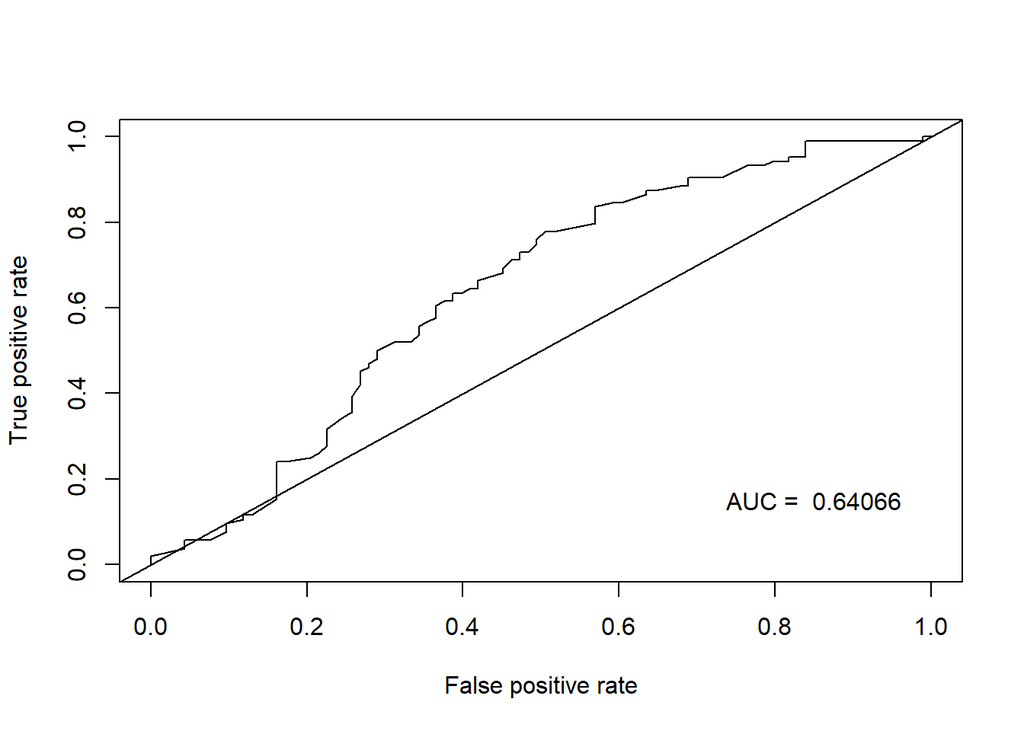

```r
pred <- prediction(predicted$posterior[,2], test$City)
perf <- performance(pred,"tpr","fpr")
plot(perf,colorize=FALSE)
AUC <- performance(pred,"auc")
abline(a = 0, b = 1)
text(x=0.85, y=0.15, paste("AUC = ", round(AUC@y.values[[1]],5)))
```

Видим, что AUC для test QDA меньше, чем для test LDA, значит LDA лучше определяет тип данных.

## Кластерный анализ:

## Выбор данных

```r
library("xlsx")
df <- read.xlsx(file = "Trees.xlsx", sheetIndex = 1)
df$bladelen <- as.double(df$bladelen)
df$petiole <- as.double(df$petiole)
df$bladewid <- as.double(df$bladewid)
df$latitude <- as.double(df$latitude)
df$logwid <- as.double(df$logwid)
df$logpet <- as.double(df$logpet)
df$loglen <- as.double(df$loglen)
df <- df[-1]
df$location <- NULL
df$latitude <- NULL
df$arch <- as.factor(df$arch)
head(df)
```

```
##   bladelen  petiole bladewid   logwid      logpet   loglen arch
## 1    33.88 1.402632    13.65 2.613740  0.33835047 3.522825    0
## 2    33.32 1.016260    10.26 2.328253  0.01612922 3.506158    0
## 3    29.35 2.392025    12.21 2.502255  0.87214029 3.379293    0
## 4    26.87 0.808787     8.70 2.163323 -0.21221968 3.291010    0
## 5    26.67 0.802767     8.41 2.129421 -0.21969077 3.283539    0
## 6    24.23 1.490145     7.70 2.041220  0.39887343 3.187592    0
```

## Описание данных

bladelen - длина листа (мм)

petiole - длина черенка

bladewid - ширина листа (мм)

logwid - логарифм ширины листа

logpet - логарифм длины черенка

loglen - логарифм длины листа

arch - тип листа (0 = плагиотропная, 1 = ортотропная)

## Визуализация данных

```r
summary(df)
```

```
##     bladelen        petiole           bladewid          logwid
##  Min.   : 2.28   Min.   : 0.1126   Min.   : 1.250   Min.   :0.2231
##  1st Qu.:14.24   1st Qu.: 0.6096   1st Qu.: 5.010   1st Qu.:1.6114
##  Median :18.34   Median : 1.0618   Median : 6.290   Median :1.8390
##  Mean   :20.08   Mean   : 2.5441   Mean   : 7.776   Mean   :1.8995
##  3rd Qu.:23.08   3rd Qu.: 1.9823   3rd Qu.: 8.410   3rd Qu.:2.1294
##  Max.   :72.30   Max.   :51.0800   Max.   :46.170   Max.   :3.8323
##      logpet            loglen       arch
##  Min.   :-2.1836   Min.   :0.8242   0:136
##  1st Qu.:-0.4950   1st Qu.:2.6561   1: 49
##  Median : 0.0600   Median :2.9091
##  Mean   : 0.1997   Mean   :2.9129
##  3rd Qu.: 0.6842   3rd Qu.:3.1390
##  Max.   : 3.9334   Max.   :4.2808
```

[output not shown]

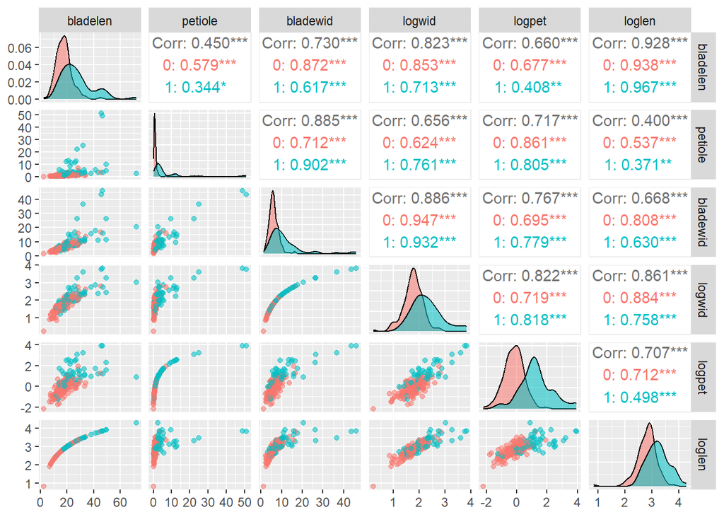

```r
num_col <- c("bladelen","petiole","bladewid","logwid","logpet","loglen")
f <- ggpairs(df, columns = num_col,  diag = list(diag = list(continuous = "densityDiag", discrete = "blankDiag", na = "blankDiag")), cardinality_threshold=NULL, mapping = aes(color = df$arch, alpha = 0.8))
print(f)
```

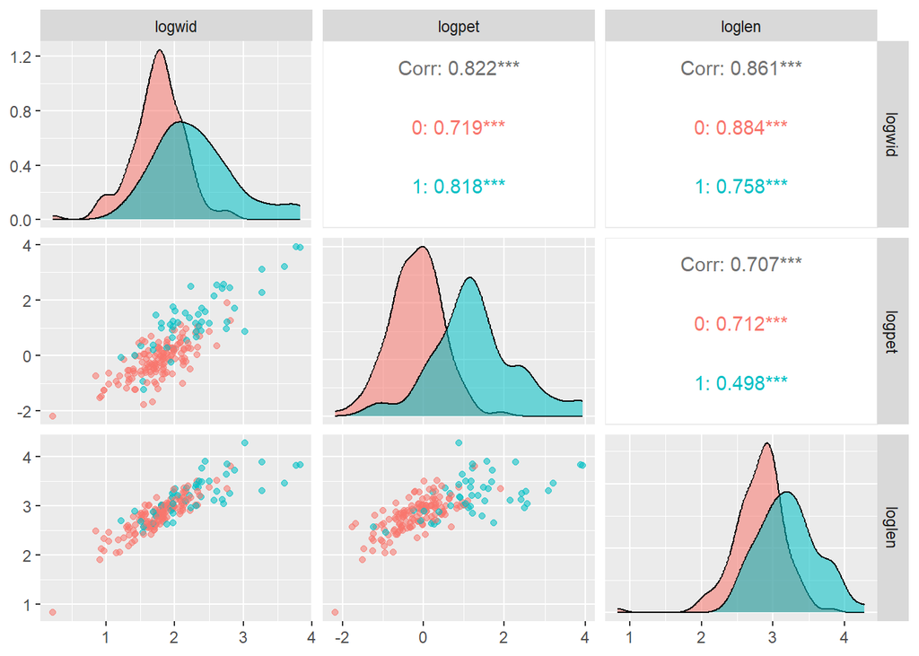

```r
num_col <- c("logwid","logpet","loglen")
f <- ggpairs(df, columns = num_col,  diag = list(diag = list(continuous = "densityDiag", discrete = "blankDiag", na = "blankDiag")), cardinality_threshold=NULL, mapping = aes(color = df$arch, alpha = 0.8))
print(f)
```

```r
library("data.table")
logdf <- data.frame(logwid = df$logwid, logpet = df$logpet, loglen = df$loglen, arch=  df$arch )
summary(logdf)
```

```
##      logwid           logpet            loglen       arch
##  Min.   :0.2231   Min.   :-2.1836   Min.   :0.8242   0:136
##  1st Qu.:1.6114   1st Qu.:-0.4950   1st Qu.:2.6561   1: 49
##  Median :1.8390   Median : 0.0600   Median :2.9091
##  Mean   :1.8995   Mean   : 0.1997   Mean   :2.9129
##  3rd Qu.:2.1294   3rd Qu.: 0.6842   3rd Qu.:3.1390
##  Max.   :3.8323   Max.   : 3.9334   Max.   :4.2808
```

## АГК

Посмотрим на данные в плоскости первых двух ГК:

```r
PCAdf <- data.frame(logwid = df$logwid, logpet = df$logpet, loglen = df$loglen, arch=  df$arch)
library("FactoMineR")
result.pca = PCA(logdf, scale.unit=TRUE, ncp=2,quali.sup=4, graph=F)
```

```r
result.pca$eig
```

```
##        eigenvalue percentage of variance cumulative percentage of variance
## comp 1  2.5947936              86.493119                          86.49312
## comp 2  0.2960622               9.868739                          96.36186
## comp 3  0.1091443               3.638142                         100.00000
```

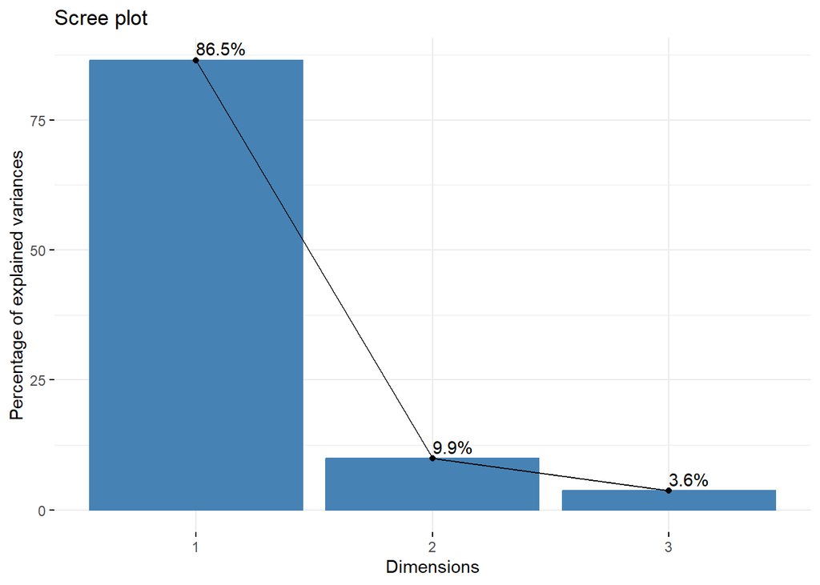

```r
library("factoextra")
fviz_eig(result.pca, addlabels = TRUE)
```

Вывод собственных векторов $U_i$:

```r
result.pca$svd$V
```

```
##           [,1]        [,2]
## [1,] 0.5981213 -0.09300878
## [2,] 0.5614876  0.75733959
## [3,] 0.5718239 -0.64636377
```

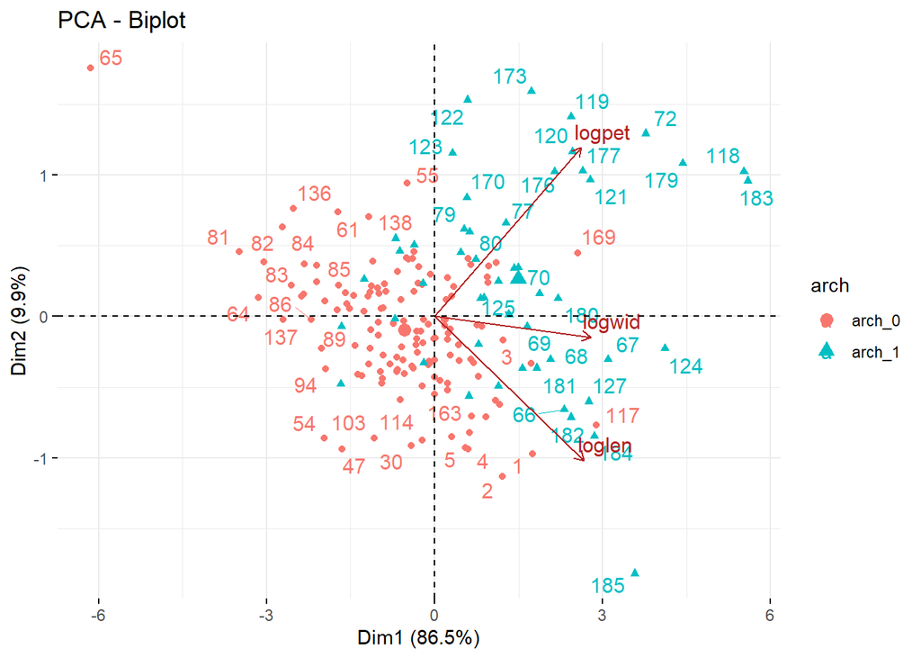

```r
fviz_pca_biplot(result.pca, repel = TRUE,habillage = 4,
                col.var = "#B22222",
                col.ind = "#008000"
                )
```

Видим, что данные представляю собой неоднородность, представляющую собой слияние двух облаков индивидов.

Стандартизуем данные:

```r
logdf.scale <- mutate(logdf, logwid = scale(logdf$logwid),
                      logpet = scale(logdf$logpet),
                      loglen = scale(logdf$loglen))

logdf$arch <- as.factor(logdf$arch)

d <- dist(logdf.scale[,1:3])
```

## Дендрограммы

Построим дендограммы:

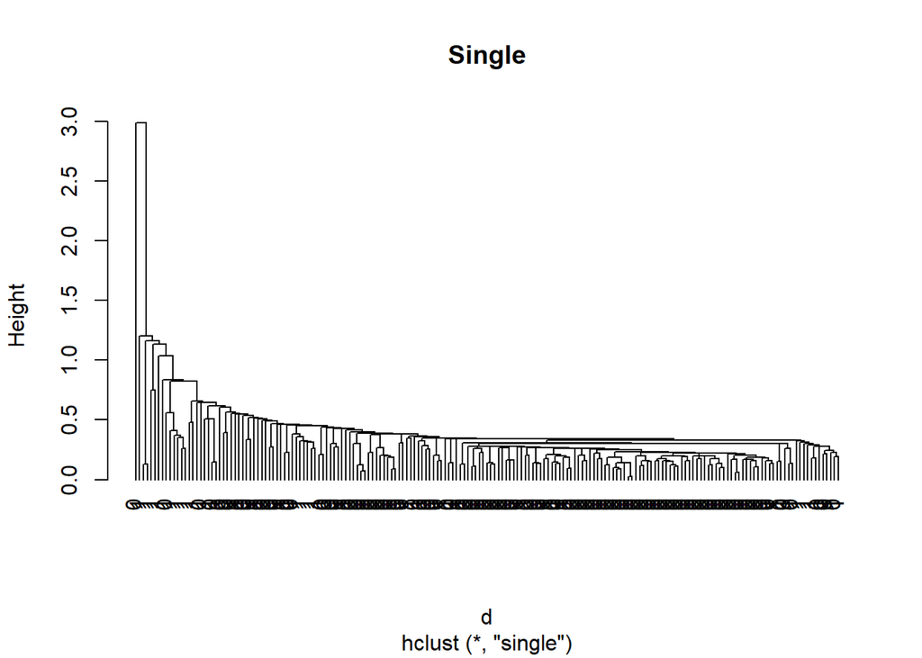

```r
library(plotly)
library(ggdendro)
library(ggplot2)
library(fastcluster)
library(dendextend)
logdf.hc.single <- hclust(d, method = 'single')
logdf.hc.complete <- hclust(d, method = 'complete')

ids <- as.numeric(factor(logdf$arch,
                  levels=unique(logdf$arch)))


plot(logdf.hc.single, hang = -1, labels = logdf$arch, main = 'Single')
```

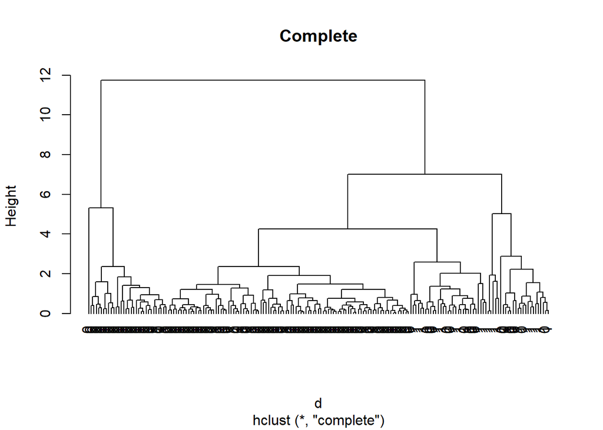

```r
plot(logdf.hc.complete, hang = -1, labels = logdf$arch, main = 'Complete')
```

На графике single видим неопределяемое число кластеров.

На графике complete видим 3 кластера.

## Model-based

Воспользуемся информационным критерием для выбора модели Model-based:

```r
library(mclust)
BIC <- mclustBIC(logdf.scale[,1:3])
BIC
```

```
## Bayesian Information Criterion (BIC):
##         EII       VII       EEI       VEI       EVI       VVI       EEE
## 1 -1592.895 -1592.895 -1603.336 -1603.336 -1603.336 -1603.336 -1160.426
## 2 -1434.303 -1432.086 -1442.604 -1439.513 -1446.337 -1443.389 -1091.040
## 3 -1340.337 -1303.667 -1349.185 -1312.433 -1352.904 -1317.274 -1108.928
## 4 -1303.350 -1240.062 -1306.762 -1242.476 -1316.041 -1253.896 -1119.191
## 5 -1269.574        NA -1272.707        NA -1305.712 -1257.065 -1118.186
## 6 -1217.950        NA -1207.944        NA -1244.216        NA -1123.852
## 7 -1195.674        NA -1196.655        NA -1242.301        NA -1138.734
## 8 -1196.068        NA -1190.573        NA -1243.294        NA -1143.552
## 9 -1198.686        NA -1236.095        NA -1260.032        NA -1169.924
##         VEE       EVE       VVE       EEV       VEV       EVV       VVV
## 1 -1160.426 -1160.426 -1160.426 -1160.426 -1160.426 -1160.426 -1160.426
## 2 -1092.223 -1090.716 -1138.538 -1084.886 -1086.408 -1086.426 -1090.901
## 3 -1110.543 -1112.797 -1141.871 -1098.384 -1103.951 -1110.065 -1120.475
## 4 -1126.273 -1146.907 -1156.343 -1114.860 -1130.936 -1130.563 -1145.588
## 5        NA -1140.203        NA -1147.226        NA -1158.093 -1192.659
## 6        NA        NA        NA -1161.839 -1193.997 -1188.275 -1207.440
## 7        NA -1201.679        NA -1168.757        NA -1218.165 -1241.737
## 8        NA -1220.666        NA -1197.894 -1246.952 -1240.422 -1272.153
## 9        NA        NA -1262.780 -1227.720 -1275.919 -1258.930 -1310.940
##
## Top 3 models based on the BIC criterion:
##     EEV,2     VEV,2     EVV,2
## -1084.886 -1086.408 -1086.426
```

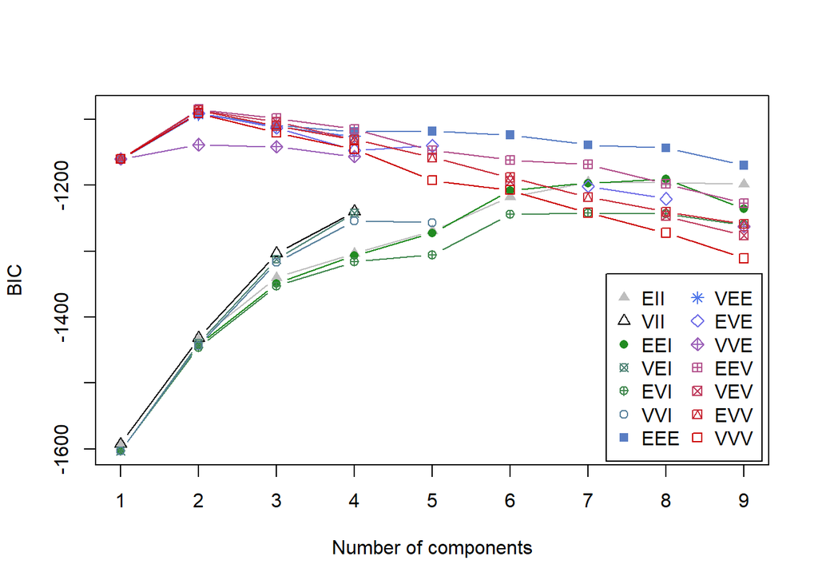

```r
plot(BIC)
```

Построим график, иллюстрирующий, как индивиды кластеризуются:

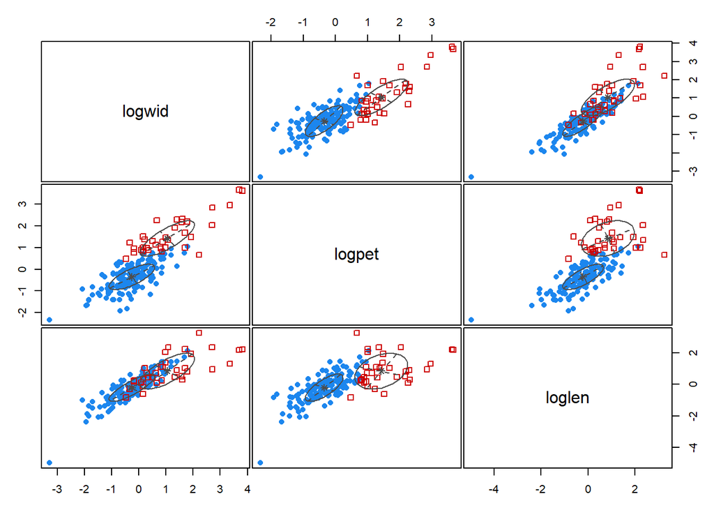

```r
opt.model <- Mclust(data = logdf.scale[,1:3], modelNames = 'VVE')
plot(opt.model, what = 'classification')
```

## K-means

Воспользуемся методом К-средних, указывая, что хотим распознать 2 кластера:

```r
logdf.km <- kmeans(logdf.scale[, 1:3], 2)
table(logdf$arch, logdf.km$cluster)
```

```
##
##       1   2
##   0 110  26
##   1  10  39
```

Построим график pairs с разделением по кластерам:

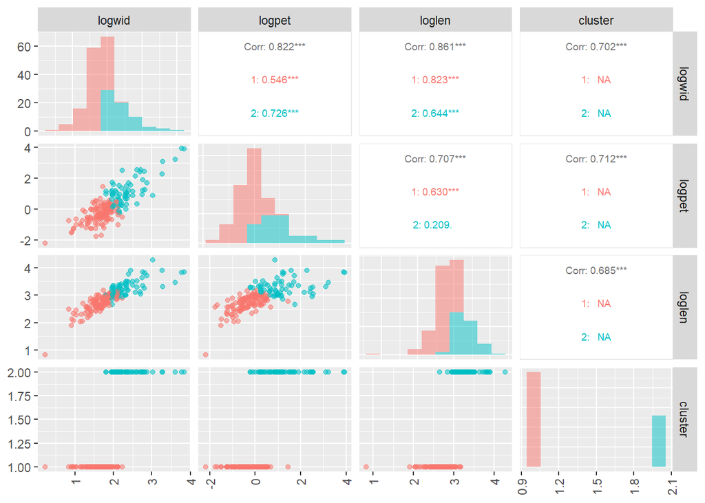

```r
logdf[, 1:3] %>% mutate(cluster = logdf.km$cluster) %>%
  ggpairs(aes(color = factor(cluster), alpha = 0.5), diag = list(continuous = wrap("barDiag", alpha = 0.5, bins = 10)),
          upper = list(continuous = wrap("cor", size = 2.5))) +
  theme(axis.text.x = element_text(angle = 90, vjust = 0.5, hjust=1))
```

По выведенным выше pairs можно сказать, что класетризация, по сути своей, представляет сигментацию (распределение будто бы просто поделено пополам), которая совпала с распределением реальных классов.